# Отчёт по лабораторной работе №4

Реализация основных моделей в агентном подходе

Автор

принадлежность

Федорова Анжелика Игоревна

Российский университет дружбы народов

Дата публикации

29 марта 2026 г.

# 1 Цель работы

Целью данной лабораторной работы является реализация агентной модели распространения инфекционного заболевания на основе классической компартментальной модели SIR (Susceptible-Infectious-Recovered) с использованием пакета `Agents.jl` на языке Julia, а также исследование влияния параметров модели (коэффициента заразности, интенсивности миграции) на динамику эпидемии.

# 2 Задание

1. Создать рабочий каталог для кода.
2. Установить необходимые пакеты.
3. Выполнить предложенный код.
4. Преобразовать код в литературный стиль.
5. Сгенерировать из литературного кода: чистый код, Jupyter Notebook, документацию в формате Quarto.
6. Выполнить код из Jupyter Notebook.
7. Интегрировать документацию в формате Quarto в отчёт.
8. Добавить в код в литературном стиле вычисление для набора параметров.
9. Сгенерировать из литературного кода с параметрами: чистый код, Jupyter Notebook, документацию в формате Quarto.
10. Выполнить код из Jupyter Notebook с параметрами.
11. Интегрировать документацию с параметрами в формате Quarto в отчёт.

# 3 Теоретическое введение

Модель SIR, предложенная Кермаком и Маккендриком в 1927 году, описывает динамику эпидемии в популяции, разделённой на три группы:

- **S (Susceptible)** — восприимчивые к заболеванию индивиды;
- **I (Infectious)** — инфицированные, способные заражать восприимчивых;
- **R (Recovered)** — выздоровевшие (или умершие), получившие иммунитет.

Классическая модель описывается системой обыкновенных дифференциальных уравнений:

$$\frac{dS}{dt} = -\beta SI, \quad \frac{dI}{dt} = \beta SI - \gamma I, \quad \frac{dR}{dt} = \gamma I$$

где $\beta$ — коэффициент передачи инфекции, $\gamma$ — скорость выздоровления.

Агентное моделирование позволяет преодолеть ограничения классического подхода: каждый индивид моделируется отдельно с уникальными характеристиками, взаимодействия происходят локально в пространстве, процессы носят стохастический характер.

В реализованной модели каждый агент — человек, обладающий свойствами:

- `status::Symbol` — состояние (`:S`, `:I`, `:R`);
- `days_infected::Int` — количество дней с момента заражения.

Агенты размещаются на графе, где узлы представляют локации (города), а рёбра — возможные перемещения между ними. Параметры модели включают: коэффициенты заразности для выявленных и невыявленных случаев, длительность болезни, время до выявления, вероятность летального исхода, вероятность повторного заражения и матрицу вероятностей миграции между локациями.

# 4 Выполнение лабораторной работы

## 4.1 Создание рабочего каталога и файлов модели

Первым шагом был создан рабочий каталог проекта `lab04/project` и выполнен переход в него. Затем с помощью редактора `nano` были созданы все необходимые файлы скриптов.

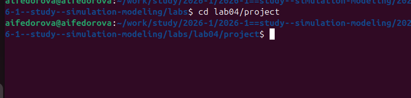

Рисунок 1: Создание рабочего каталога проекта

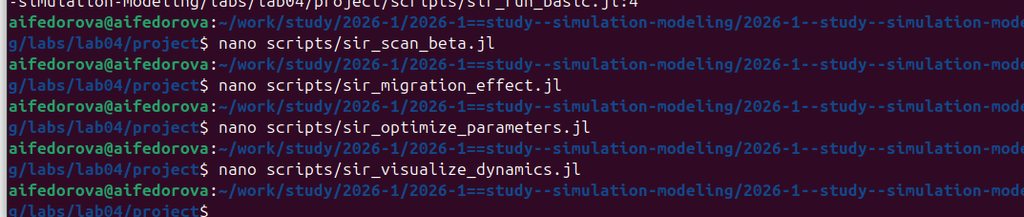

Рисунок 2: Создание скриптов модели

## 4.2 Запуск базового эксперимента

Базовый эксперимент запускался с фиксированными параметрами по умолчанию: три города по 1000 жителей, коэффициент заразности $\beta_{und} = 0.5$, период болезни 14 дней, время выявления 7 дней, вероятность смерти 0.02. Начальное заражение — 1 инфицированный в третьем городе.

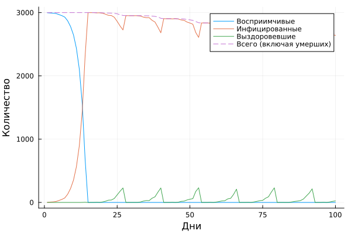

Рисунок 3: Динамика SIR-модели (базовый эксперимент)

## 4.3 Параметрическое сканирование коэффициента заразности

Скрипт `sir_scan_beta.jl` исследует, как изменение $\beta$ от 0.1 до 1.0 влияет на эпидемические показатели. Для каждого значения выполнялись 3 прогона с разными зёрнами (42, 43, 44) для учёта стохастичности.

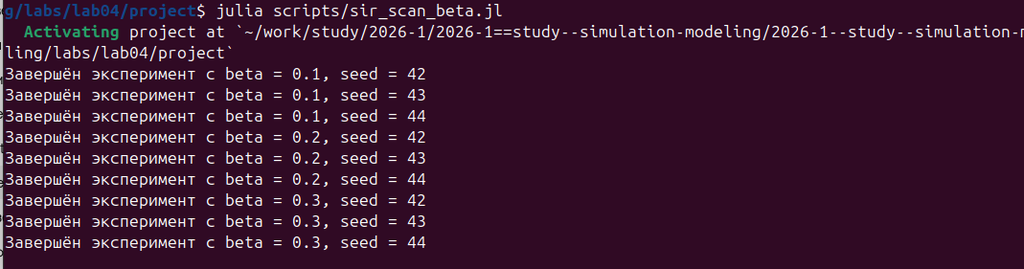

Рисунок 4: Вывод результатов сканирования beta в терминале

Усреднённые результаты по всем прогонам сведены в Таблица 1.

Таблица 1: Усреднённые результаты параметрического сканирования β (из `beta_scan_all.csv`)

| β | Пик (ср.) | Конечн. инфиц. (ср.) | Умерших (ср.) | Выздоровевших (ср.) |
| --- | --- | --- | --- | --- |
| 0.1 | 0.0009 | 0.0000 | 0.0 | 0.0011 |
| 0.2 | 0.3322 | 0.3200 | 44.0 | 0.0138 |
| 0.3 | 0.6667 | 0.6440 | 208.0 | 0.0228 |
| 0.4 | 0.6669 | 0.6297 | 226.7 | 0.0372 |
| 0.5 | 1.0000 | 0.9966 | 317.7 | 0.0034 |
| 0.6 | 1.0000 | 0.9934 | 348.0 | 0.0066 |
| 0.7 | 1.0000 | 0.9621 | 361.3 | 0.0379 |
| 0.8 | 1.0000 | 0.9463 | 356.3 | 0.0537 |
| 0.9 | 1.0000 | 0.9635 | 385.7 | 0.0365 |
| 1.0 | 1.0000 | 1.0000 | 407.3 | 0.0000 |

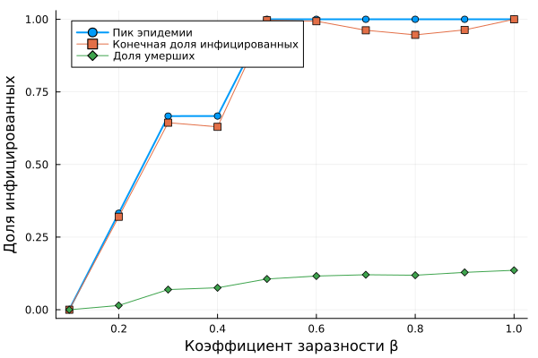

Рисунок 5: Зависимость эпидемических показателей от коэффициента заразности β

## 4.4 Исследование эффекта миграции

Скрипт `sir_migration_effect.jl` исследует влияние интенсивности миграции (от 0 до 0.5) на скорость распространения эпидемии. Данные экспериментов были сохранены в CSV-файл.

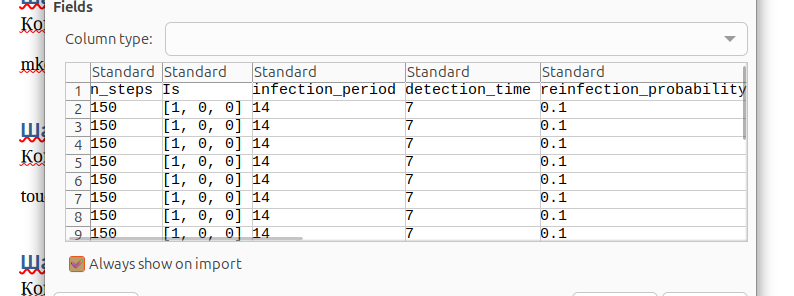

Рисунок 6: Данные экспериментов по миграции в табличном виде

Усреднённые данные по экспериментам с миграцией приведены в Таблица 2.

Таблица 2: Усреднённые результаты исследования эффекта миграции (из `migration_scan_all.csv`)

| Интенсивность миграции | Время пика (ср., дни) | Пиковая заболеваемость (ср.) |
| --- | --- | --- |
| 0.0 | 15.0 | 0.3333 |
| 0.1 | 22.0 | 1.0000 |
| 0.2 | 16.0 | 1.0000 |
| 0.3 | 17.0 | 1.0000 |
| 0.4 | 19.0 | 1.0000 |
| 0.5 | 20.0 | 1.0000 |

## 4.5 Многокритериальная оптимизация параметров

Скрипт `sir_optimize_parameters.jl` с использованием алгоритма Borg MOEA из пакета `BlackBoxOptim` искал оптимальные параметры, минимизирующие одновременно пиковую заболеваемость и долю умерших.

По результатам оптимизации найдены оптимальные параметры (табл. 3):

Таблица 3: Результаты многокритериальной оптимизации (`optimization_result.jld2`)

| Параметр | Оптимальное значение |
| --- | --- |
| $\beta_{und}$ | 0.2171 |
| Время выявления | 3 дня |
| Смертность | 0.0509 |
| Пик заболеваемости | $\approx 1.2 \times 10^{-3}$ |
| Доля умерших | $\approx 6.7 \times 10^{-5}$ |

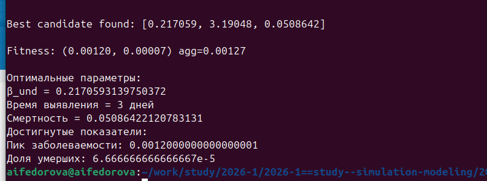

Рисунок 8: Результаты многокритериальной оптимизации в терминале

## 4.6 Сводная визуализация результатов

Скрипт `sir_visualize_dynamics.jl` загружает данные из файла `beta_scan_all.csv` и строит составной график с тремя панелями: пик и конечная доля инфицированных, число умерших, доля выздоровевших — все в зависимости от $\beta$.

На сводном графике (рис. 9) наблюдается пороговый характер: при малых $\beta$ эпидемия не развивается, при превышении порогового значения показатели резко возрастают. Стохастический характер модели проявляется в нерегулярности кривых для отдельных прогонов.

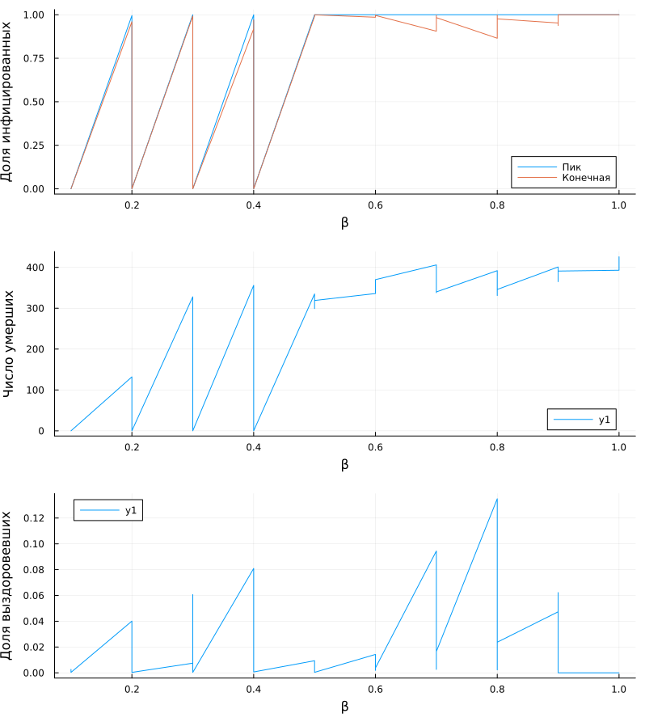

Рисунок 9: Сводная визуализация результатов параметрического сканирования

# 5 Выводы

В ходе выполнения лабораторной работы была реализована агентная модель распространения инфекционного заболевания SIR на языке Julia с использованием пакета `Agents.jl`.

Основные результаты:

- Базовый эксперимент подтвердил корректность модели: наблюдается характерная эпидемическая волна с повторными вспышками за счёт вероятности повторного заражения и смертности.
- Параметрическое сканирование коэффициента заразности показало наличие порогового значения $\beta \approx 0.2$, при превышении которого эпидемия охватывает большую часть популяции, что соответствует теоретическому условию $R_0 > 1$.
- Исследование эффекта миграции продемонстрировало, что даже небольшая интенсивность перемещений между городами приводит к быстрому распространению инфекции на всю метапопуляцию.
- Многокритериальная оптимизация позволила найти параметры (раннее выявление — 3 дня, умеренная заразность $\beta \approx 0.217$), при которых одновременно минимизируются пиковая заболеваемость и смертность.

Агентный подход показал свои преимущества перед классическими моделями на ОДУ: учёт стохастичности, пространственной структуры и индивидуальных характеристик позволяет получить более реалистичную картину распространения эпидемии.